# Bioestadística Uno

John Jairo Estrada Alvarez

30 de enero de 2016

# 1 Objetivos específicos

- Describir los conceptos de población, muestra, variables y datos, así como también, discriminar entre los diversos tipos de variables.
- Producir una descripción tabular y gráfica de los datos de la muestra y resumir tales datos mediante estadísticos de tendencia central, dispersión y distribución, todo esto apoyado en un programa computacional de estadística.
- Aprender el concepto de probabilidad considerando la misma como una estrategia para cuantificar fenómenos aleatorios y aplicar la teoría matemática básica sobre el cálculo de probabilidades.
- Explicar el concepto de variable aleatoria y de modelo de distribución de probabilidad, así como también, discriminar entre diversos tipos de variables aleatorias y sus modelos asociados (por ejemplo, Binomial, Normal, Poisson, etc.)

# 2 Conceptos Introductorios

- **¿De donde viene la palabra estadı́stica y que significa?**
  - **Respuesta**: Viene del latı́n status. Significa estado. La estadı́stica comenzó colectando  
    y resumiendo información (o datos) sobre el estado. Aún hoy dı́a, un segmento grande del público en general piensa en la estadı́stica como un sinónimo de datos, tablas y gráficas.

A comienzos del siglo XX algunos matemáticos como Karl Pearson y Ronald A Fisher realizaron avances matemáticos importantes que posicionaron la Estadı́stica como una ciencia independiente para ser usada en el análisis e interpretación de los datos en la investigación cientı́fica.

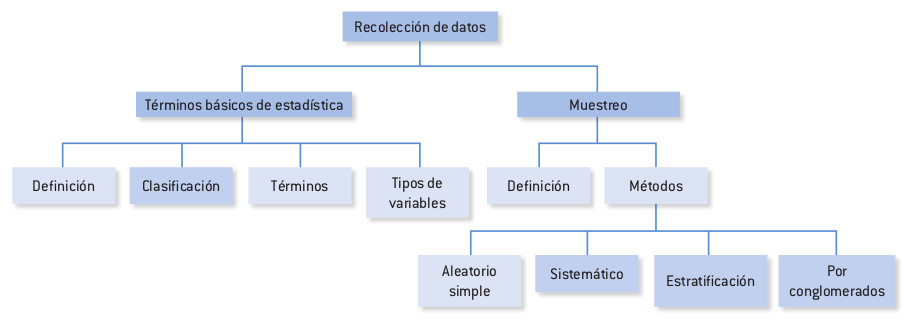

Figure 2.1: Fundamentos de la estadística [Imagen tomada de (Gutierrez Banegas, Leon, & others, 2012) pág $4$]

- **¿Qué es la estadística?**
  - **Respuesta**: Es el arte de la decisión frente a la incertidumbre. Milton (2001,pág. 1) Es la disciplina que ofrece un conjunto de técnicas para diseñar el proceso de colectar, resumir e interpretar datos, ası́ como también, obtener conclusiones o generalidades a partir de ellos. Johnnson & Bahttachaaryya (1996, pág. 3)
  - **Respuesta**:(Lind, Marchal, Wathen, Obón León, & León Cárdenas (2012)) Ciencia que recoge, organiza, presenta, analiza e interpreta datos con el find e proporcionar una toma de decisiones más eficaz.
  - **Respuesta**:(Martínez (2012)) Sistema o método usado en la recolección, organización, análisis y descripción numérica de la información. También se puede decir que la estadística estudia el comportamiento de hechos o fenómenos de grupo.

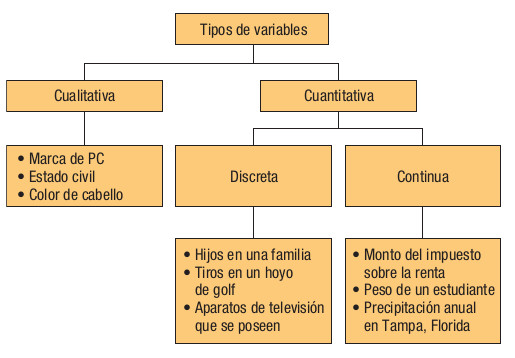

Figure 2.2: Resumen tipos de variables [Imagen tomada de (Lind et al., 2012) pág $9$]

- **¿Qué es una variable?**
  - **Respuesta**: Una variable representa una caracterı́stica o rasgo compartido por un grupo de elementos (objetos o entidades), que toma más de un posible valor (numérico o de texto) entre los elementos del grupo.
- **Variable categórica (ó cualitativa)**
  - Si sus valores no se pueden asociar naturalmente a un número (no se puede hacer operaciones aritméticas con ellos)
    1. **Nominales**: Si sus valores no tiene un orden natural
       1. Ejemplos: Sexo, rasgos fenotípicos y genotípicos, Fumar Si/No, Color, Nacionalidad, etc
    2. **Ordinales**: Si sus valores se pueden ordenar de forma natural
       2. Ejemplos: Mejora de un tratamiento, resistencia al dolor, grado de felicidad, etc
- **Variable cuantitativa**: Si sus valores son numéricos (si se pueden hacer operaciones aritméticas con ellos).
  - **Continuos**: Si toma valores en una escala continua en los números reales.
  - **Discretos**: Si toma valores enteros. Por lo general resultan del proceso de contar.

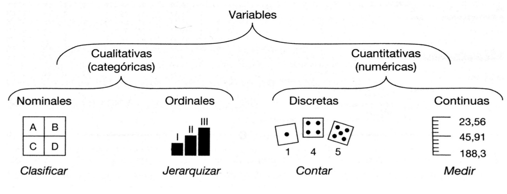

- **¿Qué es un dato?**
  - **Respuesta**: Un dato es el resultado de realizar una observación o medición sobre un elemento del grupo de interés. Se puede tener un dato en una sola variable o en más de una variable.

El término en plural datos o conjuntos de datos hace referencia al conjunto de observaciones realizadas sobre cada uno de los elementos del grupo de interés

- **¿Qué es una unidad de observación?**
  - **Respuesta**: Es un elemento ó persona a la cual se le miden una (ó más) variables sobre ella.
- **¿Qué es una población?**
  - **Respuesta**: Una población es la colección entera de unidades de observación que se desea estudiar. Por lo general, tal colección esta definida por ciertas condiciones fı́sicas, biológicas, espaciales o temporales establecidas por los objetivos de la investigación. En muchas ocasiones, las poblaciones son demasiado grandes o incluso infinitas
- **¿Qué es una muestra?**
  - **Respuesta**: Una muestra es un subconjunto de elementos de la población. La muestra se obtiene para generalizar a toda la población lo observado en la muestra. Cualidades de la muestra
    1. Representativa de toda la población
    2. Tomada al azar (es decir todos los elementos de la población tienen la misma probabilidad)

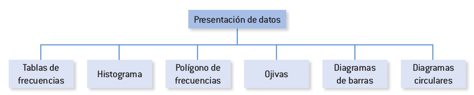

Figure 2.3: Presentación de datos [Imagen tomada de (Gutierrez Banegas et al., 2012) pág $9$]

# 3 Estradística descriptiva

## 3.1 Qué es la Estradística descriptiva?

Es el conjunto de técnicas para organizar y describir un conjunto de datos (muestra) utilizando métodos numéricos y gráficos que resumen y presentan la información contenida en ellos.

### 3.1.1 Repaso de R en Rstudio

Los conceptos básicos para el manejo de R los recorremos usando el documento elaborado por Vicente Coll y Pedro J Pérez (Junio 2017) [Página web](https://www.uv.es/pjperez/curso_R/tt_2_conceptos_basicos_R.html)

Ver también la página web [Todo sobre programción en R](https://r-coder.com/inicio/)

### 3.1.2 Páginas donde se puede trabajar R en línea

Una página donde se puede elaborar prácticas básicas para uso de comandos en R es: [Compile R online](https://www.tutorialspoint.com/execute_r_online.php)

También se puede trabajar en línea con las siguientes páginas.

- [R en línea Dos](https://rdrr.io/snippets/)
- [R en línea Tres](https://paiza.io/es/projects/new)
- [R en línea Cuatro](https://www.mycompiler.io/new/r)

**Ejercicios para entrenar el manejo datos**

- Ejemplo3

### 3.1.3 Los aspectos importantes de los datos

1. **Destribución de frecuencias**

Cómo están repartidos o distribuidos los datos en el rango de valores de la variable evaluada?

- Ejemplo1

Se entrevistó 20 jóvenes para conocer el número de refrescos de cola que beben al día. Las respuestas obtenidas son los siguientes:

$$\begin{equation}
\begin{matrix}
5 & 2 & 2 & 4 & 5\\
1 & 1 & 4 & 2 & 1\\
3 & 5 & 1 & 0 & 5\\
0 & 3 & 2 & 3 & 4
\end{matrix}
\end{equation}$$

Frecuencia relativa

```r
Pc <- c(5,1,3,0,2,1,5,3,2,4,1,2,4,2,0,3,5,1,5,4)
Tabla1 <- as.data.frame(sort(table(TC3 =Pc),decreasing = T))
Tabla2 <- transform(Tabla1, FreAc = cumsum(Freq))
Tabla3 <- transform(Tabla2,Rel = round(prop.table(Freq),3))
 library(kableExtra)
      library(dbplyr)
      kable(Tabla3 , 'html') %>%
        kable_styling(full_width = F)
```

| TC3 | Freq | FreAc | Rel |
| --- | --- | --- | --- |
| 1 | 4 | 4 | 0.20 |
| 2 | 4 | 8 | 0.20 |
| 5 | 4 | 12 | 0.20 |
| 3 | 3 | 15 | 0.15 |
| 4 | 3 | 18 | 0.15 |
| 0 | 2 | 20 | 0.10 |

Frecuencia relativa y acumulada

```r
Pc <- c(5,1,3,0,2,1,5,3,2,4,1,2,4,2,0,3,5,1,5,4)
Tabla1 <- as.data.frame(sort(table(TC3 =Pc),decreasing = T))
Tabla2 <- transform(Tabla1, FreAc = cumsum(Freq))
Tabla3 <- transform(Tabla2,Rel = round(prop.table(Freq),3))
Tabla4 <- transform(Tabla3,RelAc = round(cumsum(prop.table(Freq)),3))
# tabla4
 library(kableExtra)
      library(dbplyr)
      kable(Tabla4 , 'html') %>%
        kable_styling(full_width = F)
```

| TC3 | Freq | FreAc | Rel | RelAc |
| --- | --- | --- | --- | --- |
| 1 | 4 | 4 | 0.20 | 0.20 |
| 2 | 4 | 8 | 0.20 | 0.40 |
| 5 | 4 | 12 | 0.20 | 0.60 |
| 3 | 3 | 15 | 0.15 | 0.75 |
| 4 | 3 | 18 | 0.15 | 0.90 |
| 0 | 2 | 20 | 0.10 | 1.00 |

Comando para obtener el Rango de una variable: Ej obtener el rango de la variable EDAD

```r
Pc <- c(5,1,3,0,2,1,5,3,2,4,1,2,4,2,0,3,5,1,5,4)
range(Pc, na.rm=TRUE)
```

```
## [1] 0 5
```

```r
# El parámetro na.rm=TRUE se usa para que ingore la presencia de valores perdidos
```

Comando para obtener el número de clases para la variable EDAD:

```r
Pc <- c(5,1,3,0,2,1,5,3,2,4,1,2,4,2,0,3,5,1,5,4)
nclass.Sturges(Pc)  # Número de intervalos
```

```
## [1] 6
```

Comando para obtener el límites extremo derecho; extremo derecho en cada una de las clases:

```r
seq(0,5,length=nclass.Sturges(Pc))  # Límites de los intervalos
```

```
## [1] 0 1 2 3 4 5
```

Comando para obtener la Tabla de frecuencias absolutas para la variable EDAD

```r
intervalosEDAD=cut(Pc,breaks=seq(0,5,length=nclass.Sturges(Pc)),include.lowest=TRUE)
intervalosEDAD # Se muestran los intervalos de edad, uno correspondiente a cada edad observada
```

```
##  [1] (4,5] [0,1] (2,3] [0,1] (1,2] [0,1] (4,5] (2,3] (1,2] (3,4] [0,1] (1,2]
## [13] (3,4] (1,2] [0,1] (2,3] (4,5] [0,1] (4,5] (3,4]
## Levels: [0,1] (1,2] (2,3] (3,4] (4,5]
```

Comando para obtener la Tabla de frecuencias absolutas para la variable EDAD

```r
table(intervalosEDAD)
```

```
## intervalosEDAD
## [0,1] (1,2] (2,3] (3,4] (4,5]
##     6     4     3     3     4
```

```r
Pc <- c(5,1,3,0,2,1,5,3,2,4,1,2,4,2,0,3,5,1,5,4)
Tabla1 <- as.data.frame(sort(table(TC3 =Pc),decreasing = T))
Tabla2 <- transform(Tabla1, FreAc = cumsum(Freq))
 library(kableExtra)
      library(dbplyr)
      kable(Tabla2 , 'html') %>%
        kable_styling(full_width = F)
```

| TC3 | Freq | FreAc |
| --- | --- | --- |
| 1 | 4 | 4 |
| 2 | 4 | 8 |
| 5 | 4 | 12 |
| 3 | 3 | 15 |
| 4 | 3 | 18 |
| 0 | 2 | 20 |

**Frecuencia absoluta**

Comando para generar la GRAFICA DE BARRAS de frecuencias absolutas relacionada a la variable Pc

| TC3 | Freq |
| --- | --- |
| 1 | 4 |
| 2 | 4 |
| 5 | 4 |
| 3 | 3 |
| 4 | 3 |
| 0 | 2 |

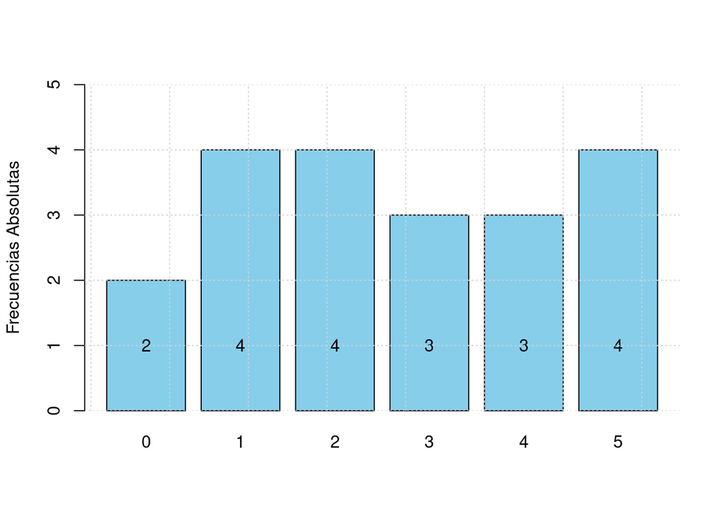

```r
tb <- table(Pc)
barras <- barplot(tb,col='skyblue', ylab ="Frecuencias Absolutas", ylim=c(0,5))
text(barras,c(1,1),tb)
grid()
```

Comando para generar la GRAFICA DE BARRAS de frecuencias relativas relacionada a la variable Pc

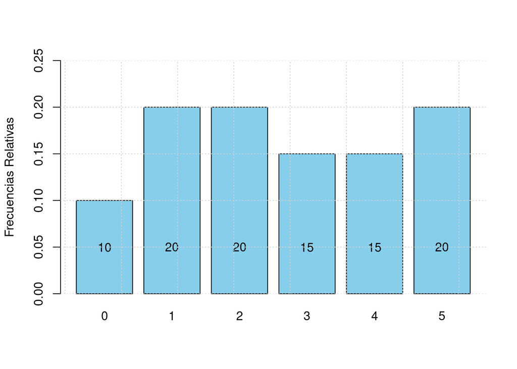

```r
tbp <- prop.table(table(Pc))
barras2 <- barplot(tbp,col='skyblue', ylab ="Frecuencias Relativas", ylim=c(0,0.25))
text(barras2,c(0.05,0.05),tbp*100)
grid()
```

```r
Pc <- c(5,1,3,0,2,1,5,3,2,4,1,2,4,2,0,3,5,1,5,4)
k12 <-ncol(matrix(Pc,1,20))
k11<-round(1 + (3.322*log10(k12)),digits = 0)
k11
```

```
## [1] 5
```

```r
Px <- as.data.frame(table(x=factor(cut(Pc,breaks=k11))))

PPx <- transform(Px,
               FreAc =cumsum(Freq),
               Rel=round(prop.table(Freq),4),
               RelAc=round(cumsum(prop.table(Freq)),4))
    library(kableExtra)
    library(dbplyr)
    kable( PPx, 'html', digits = 2) %>%
    kable_styling(full_width = F)
```

| x | Freq | FreAc | Rel | RelAc |
| --- | --- | --- | --- | --- |
| (-0.005,1] | 6 | 6 | 0.30 | 0.30 |
| (1,2] | 4 | 10 | 0.20 | 0.50 |
| (2,3] | 3 | 13 | 0.15 | 0.65 |
| (3,4] | 3 | 16 | 0.15 | 0.80 |
| (4,5] | 4 | 20 | 0.20 | 1.00 |

Comando para obtener el histograma (ó GRAFICO) asociado a la tabla de frecuencias absolutas

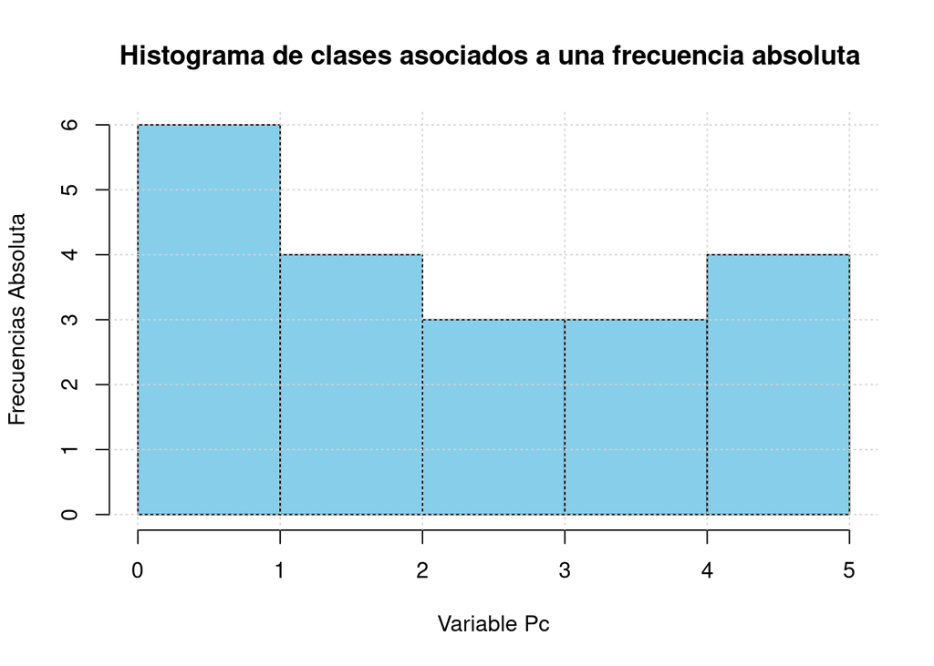

```r
Pc <- c(5,1,3,0,2,1,5,3,2,4,1,2,4,2,0,3,5,1,5,4)
# table(intervalosEDAD)
tbp1 <- table(Pc)
grahis <-hist(Pc, ylab ="Frecuencias Absoluta", main ="Histograma de clases asociados a una frecuencia absoluta ", col="skyblue", xlab = "Variable Pc")
# text(grahis,c(1,1),tbp1)
grid()
```

Comando para obtener la caja de bigotes (ó GRAFICO) asociado a la variable EDAD

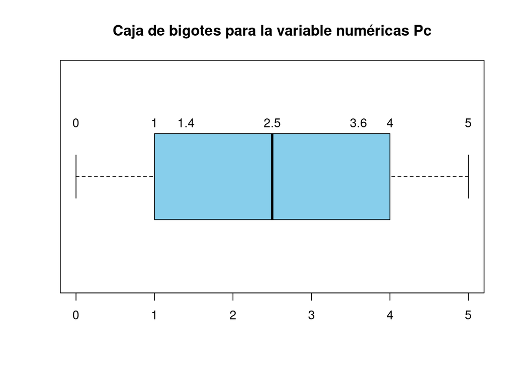

```r
boxplot(Pc,
        main="Caja de bigotes para la variable numéricas Pc",
        col="skyblue",horizontal=T)
values <- c(round(boxplot.stats(Pc)$conf, 1), boxplot.stats(Pc)$stats)
text(x = values, labels = values, y = 1.25)
```

```r
Pc <- c(5,1,3,0,2,1,5,3,2,4,1,2,4,2,0,3,5,1,5,4)
summary(Pc)
```

```
##    Min. 1st Qu.  Median    Mean 3rd Qu.    Max.
##    0.00    1.00    2.50    2.65    4.00    5.00
```

- Ejemplo2

**Tecnología**: Se pregunto a 30 jóvenes cuántas horas didicaban cada día a navegar en internet (el tiempo que dedican a sesiones de chat y a las redes sociales quedan incluido). Los resultados son los siguientes:

$$\begin{equation}
\begin{matrix}
2.5 & 4.5 & 5.8 & 2.2 & 5.7\\
5.3 & 4.0 & 0.9 & 2.5 & 2.3\\
3.2 & 4.9 & 2.7 & 3.7 & 3.8\\
4.9 & 2.8 & 3.6 & 4.2 & 3.1\\
7.2 & 1.9 & 5.9 & 3.3 & 2.9\\
1.1 & 1.7 & 2.6 & 3.1 & 4.4
\end{matrix}
\end{equation}$$

# 4 Proceso para presentar datos en forma agrupada

- Obtener el tama~no de la muestra $(n)$.
- Hallar el m'inimo y el m'aximo de los datos
- Obtener el recorrido de la variable (o rango) el cual se define como:

$$R=x_{max}-x_{min}$$

- Calcular el número de intervalos (o clases) a utilizar.

Estos intervalos tambión se llaman **intervalos de clase**. La **regla de Sturges** indica que el número de intervalos de clase recomendado, es:
$$k=1+3,322log_{10}(n)$$
donde $n$ es el tamaño de la muestra.

- Obtener la amplitud de clase. La amplitud de cada celda se calcula con la fórmula.

  $$a=\dfrac{R}{k}=\dfrac{x_{max}-x_{min}}{k}$$
- Los intervalos seleccionados no pueden solaparse.
- Contar el número de datos que caen en cada intervalo de clase. Dicho conteo se llama la **frecuencia absoluta** de clase.
- Calcular la **frecuencia relativa de clase** dividiendo la **frecuencia absoluta de clase** por el número total de datos en la muestra.
- El diagrama ubica la variable evaluada en el eje $x$, y sobre este eje, levanta rectángulos cuyas áreas son iguales o proporcionales a la frecuencia absoluta $(n_i)$ o relativa $(f_i)$ de cada intervalo de clase.
- Ejemplo3

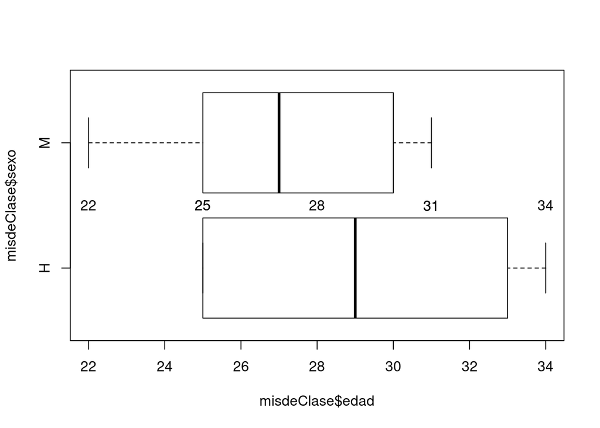

```r
edad <- c(22, 34, 29, 25, 30, 33, 31, 27, 25, 25)
tiempo <- c(14.21, 10.36, 11.89, 13.81, 12.03, 10.99, 12.48, 13.37, 12.29, 11.92)
sexo <- c("M","H","H","M","M","H","M","M","H","H")
misdeClase <- data.frame(edad,tiempo,sexo)
boxplot(misdeClase$edad~misdeClase$sexo,horizontal = T)
Pc <- misdeClase$edad
values <- c(round(boxplot.stats(Pc)$conf, 1), boxplot.stats(Pc)$stats)
text(x = values, labels = values, y = 1.5)
```

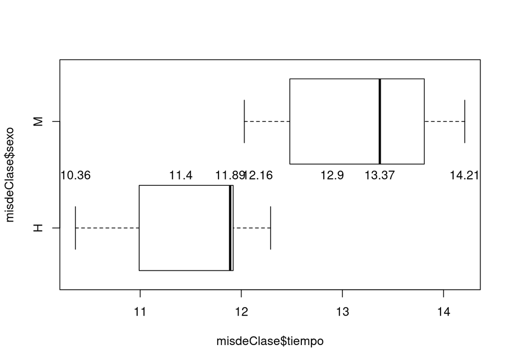

[figure not shown]

```r
edad <- c(22, 34, 29, 25, 30, 33, 31, 27, 25, 25)
tiempo <- c(14.21, 10.36, 11.89, 13.81, 12.03, 10.99, 12.48, 13.37, 12.29, 11.92)
sexo <- c("M","H","H","M","M","H","M","M","H","H")
misdeClase <- data.frame(edad,tiempo,sexo)
boxplot(misdeClase$tiempo~misdeClase$sexo,horizontal = T)
P1c <- misdeClase$tiempo
values <- c(round(boxplot.stats(P1c)$conf, 1), boxplot.stats(P1c)$stats)
text(x = values, labels = values, y = 1.5)
```

## 4.1 Críterio datos **atípicos**

$$\text{Dato atípico}>Q_{3}+1.5(Q_{3}-Q_{1})$$
$$\text{Dato atípico}<Q_{1}-1.5(Q_{3}-Q_{1})$$

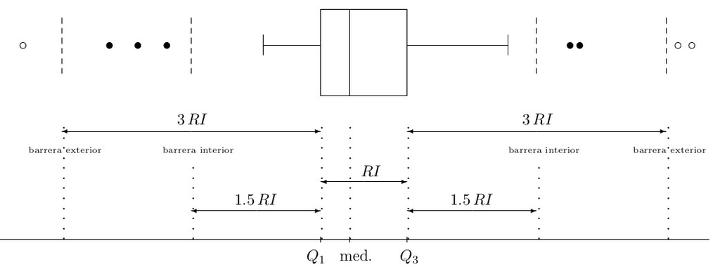

# 5 Datos no agrupados

Las siguientes son recomendaciones en el tratamiento de datos no agrupados.

- Ordenar los datos de menor a mayor.
- Colocar una etiqueta numérica para tener clara la posición que tiene el datos en el ordenamiento.

## 5.1 Medidas de posición

Todas ellas a su manera tratan de dar una idea del número alrededor del cual se centra a todo el conjunto de datos.

### 5.1.1 La media aritmética para datos no agrupados $(\bar{x})$

$$\bar{x}=\dfrac{\sum^{n}_{i=1}x_{i}}{n}$$

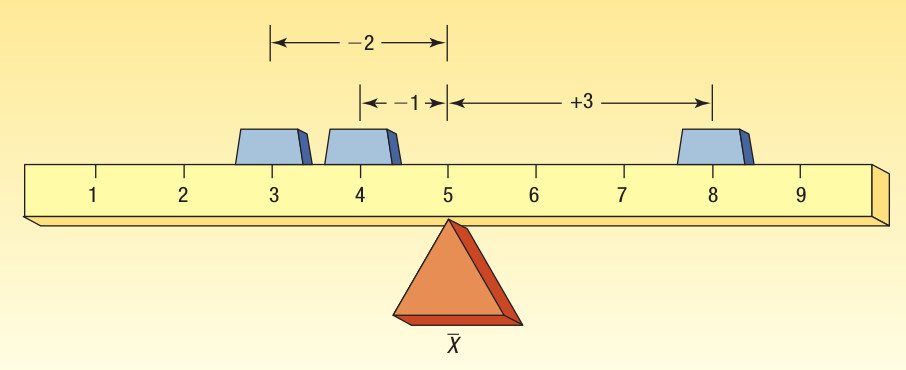

### 5.1.2 La mediana para datos no agrupados

El número $n$ es impar

$$Me=X_{\frac{n+1}{2}}$$
El número $n$ es par

$$Me=\dfrac{X_{\frac{n}{2}}+X_{\frac{n+2}{2}}}{2}$$

### 5.1.3 La Moda $(M_{0})$

Es la medida de posición que indica la magnitud del valor que se presenta con más frecuencia en una serie de datos.

## 5.2 Cálculo de cuartiles en datos NO agrupados

Sea el conjunto de datos no agrupados:

$$20,23,24,24,24,25,29,31,31,33,34,36,36,37,39,39,40,40,41,45$$
* Proceso $Q_{1}:$ El primer cuartil es el valor mayor que el $25 \%$ de los valores de la distribuci'on. como N=20 resulta que

$$\dfrac{n}{4}=5$$
el primer cuartil es la media aritm'etica de dicho valor y el siguiente:

$$Q_{1}=\dfrac{24+25}{2}=24.5$$
Sea el conjunto de datos no agrupados:

$$20,23,24,24,24,25,29,31,31,33,34,36,36,37,39,39,40,40,41,45$$

- Proceso $Q_{2}:$

El segundo cuartil es, evidentemente, la medianan de la distribución, es el valor de la variable que ocupa el lugar central en un conjunto de datos ordenados. Ccomo N=20 resulta que

$$\dfrac{n}{2}=10$$

la mediana es la media aritm'etica de dicho valor y el siguiente:

$$M_{e}=Q_{2}=\dfrac{33+34}{2}=33.5$$
Sea el conjunto de datos no agrupados:

$$20,23,24,24,24,25,29,31,31,33,34,36,36,37,39,39,40,40,41,45$$

- Proceso $Q_{3}:$

El tercer cuartil es, el valor que sobrepasa al $75 \%$ de los valores de la distribución. En nuestro caso, como $N=20$ resulta que

$$\dfrac{3n}{4}=15$$

resulta:

$$Q_{3}=\dfrac{39+39}{2}=39$$

# 6 Datos agrupados

Dada la siguiente distribución correspondiente al salario samanal en dòlares para un grupo de obreros en una empresa petrolera tradicional

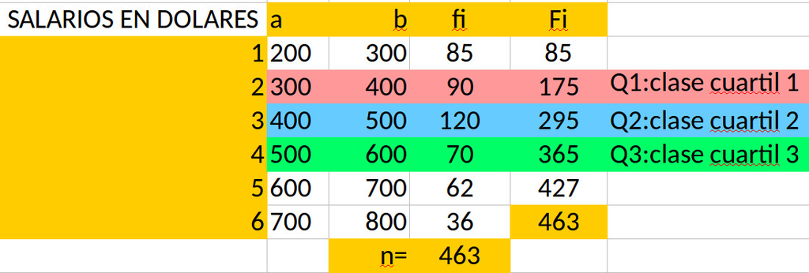

Obtener:

- La media $(\bar{x}=?)$
- La mediana $(Me=?)$
- La moda $(Mo=?)$
- El primer cuartil $(Q_1=?)$
- El segundo cuartil $(Q_2=?)$
- El tercer cuartil $(Q_3=?)$
- La varianza $(\sigma^2=?)$
- La desviación estándar $(\sqrt{\sigma^2}=\sigma=?)$

En la distribución de frecuencias correspondiente al peso en $Kg$ para un grupo de obreros.

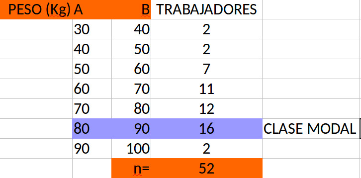

Calcule:

- La media $(\bar{x}=?)$
- La mediana $(Me=?)$
- La moda $(Mo=?)$
- El primer cuartil $(Q_1=?)$
- El segundo cuartil $(Q_2=?)$
- El tercer cuartil $(Q_3=?)$
- La varianza $(\sigma^2=?)$
- La desviación estándar $(\sqrt{\sigma^2}=\sigma=?)$

Para la tabla de distribución en frecuencias correspondiente a las horas extras laboradas por un grupo de obreros

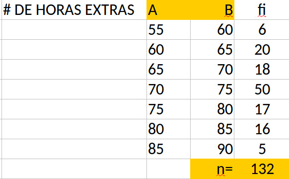

Realice el cálculo de:

- La media $(\bar{x}=?)$
- La mediana $(Me=?)$
- La moda $(Mo=?)$
- El primer cuartil $(Q_1=?)$
- El segundo cuartil $(Q_2=?)$
- El tercer cuartil $(Q_3=?)$
- La varianza $(\sigma^2=?)$
- La desviación estándar $(\sqrt{\sigma^2}=\sigma=?)$

[figure not shown]

Figure 6.1: Medidas de tendencia central y de dispersión [Imagen tomada de (Gutierrez Banegas et al., 2012) pág $51$]

- **Simétrica**, si la mayor concentración de datos se localiza en el centro de la distribución
- **Sesgada a derecha**, si la mayor concentración de datos se localiza a la izquierda de la distribución
- **Sesgada a izquierda**, si la mayor concentración de datos se localiza a la derecha de la distribución

## 6.1 La media para datos agrupados $(\bar{x})$

$$\bar{x}=\dfrac{\sum_{i=1}^{n}f_{i}x_{i}}{n}$$

## 6.2 La mediana para datos agrupados $(Me)$

Proceso:

- Se elabora la tabla de frecuencias de datos con diferentes intervalos de clases, se ubican las frecuencias absolutas $n_{i}$ y se calculan las frecuencias acumuladas $F_{i}$ de la distribución.
- Se determina la ubicación o posición de la mediana en el intervalo de la distribución de frecuencia, mediante la fórmula $\frac{n}{2}$. Esta clase se llamará clase de la mediana. El resultado obtenido determinarí la clase donde se encuentra ubicada $f_{i}$ sea igual o superior a este resultado. Luego se aplica la fórmula:

$$Me=L_{i}+\left( \dfrac{\frac{n}{2}-F_{i-1}}{f_{i}}\right) I_c$$

- $\frac{n}{2}$: Posición de la mediana.**()**

Este valor de posición se comparó con las datos que se tienen en la columna (**$F_i$**), y posteriormente se selecciona el valor más proximo pero mayor que $\frac{n}{2}$. El intervalo donde se encontro dicho valor se denomina “**Intervalo de la mediana**”

- $L_{i}$: Es el limite inferior de la clase donde se ubicada la mediana.
- $F_{(i-1)}$: Es el valor de la frecuencia acumulada anterior a la clase mediana.
- $f_{i}$: Es el valor de la frecuencia de clase donde se encuentra la mediana.
- $I_{c}$: Es el tamaño del intervalo de clase.
- $n$: Es el número total de datos de la distribuación en estudio.

## 6.3 Los cuartiles para datos agrupados $(Q_c)$

$$Q_c=L_{i}+\left( \dfrac{\frac{cn}{4}-F_{(i-1)}}{f_{i}}\right) I_c$$

Se inicia determinando la posición que ocupa el cuartil solicitado mediante la fórmula

Posición de clase para el cuartil $c$;

$$P_{c}=\dfrac{cn}{4}$$
$\frac{cn}{4}$: Posición que ocupa el cuartil en la distribución de frecuencia.

$c$: Corresponde al número del cuartil solicitado: $1,2,3$.

$L_{i}$: Es el limite inferior de la clase donde se encuentra ubicado el cuartil deseado.

## 6.4 La moda para datos agrupados $(Mo)$

$$M_{o}=L_{i}+\left( \dfrac{\vartriangle_{1}}{\vartriangle_{1}+\vartriangle_{2}}\right) I_c$$

$L_{i}$: Es el limite inferior de la clase modal.

$\vartriangle_{1}$:Es la diferencia entre la frecuencia absoluta de la clase modal y la frecuencia de la clase anterior a la modal.

$\vartriangle_{2}$:Es la diferencia entre la frecuencia absoluta de la clase modal y la frecuencia de la clase siguiente a la modal.

$I_{c}$: Es el tamaño del intervalo de clase.

## 6.5 Cálculo de Deciles para datos agrupados.

$$D_k=L_{i}+\left( \dfrac{\frac{kn}{10}-F_{(i-1)}}{f_{i}}\right) I_c$$

## 6.6 Percentil

### 6.6.1 Fórmula para datos agrupados.

$$P_k=L_{i}+\left( \dfrac{\frac{kn}{100}-F_{(i-1)}}{f_{i}}\right) I_c$$

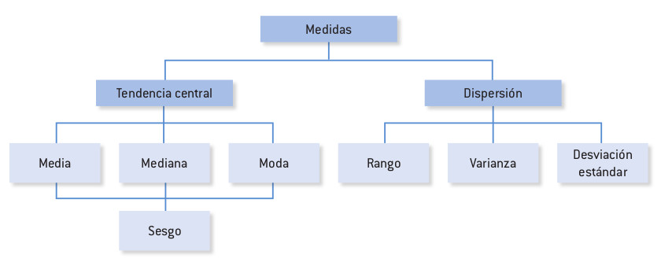

Figure 6.2: Medidas de tendencia central y de dispersión [Imagen tomada de (Gutierrez Banegas et al., 2012) pág $46$]

# 7 Medidas de dispersión

La medida de dispersión es un número que nos indica el grado de separación en un conjunto de datos. Si el valor de la dispersión es pequeño (respecto de la unidad de medida) entonces hay una gran uniformidad entre los datos (homogénea)

Por el contrario, un gran valor en la dispersión nos indica poca uniformidad (heterogénea). Cuando es cero quiere decir que todos los datos son iguales. Las medidas de dispersión se clasifican en dos grupos

- **Dispersión absoluta**

Entre ellas el rango, el rango intercuartilico, la desviación media, la varianza y la desviación típica.

$$\text{Para datos no agrupados}: \ \text{DM}=\dfrac{\sum\left| x_{i}-\bar{x} \right| }{n}=\dfrac{\sum\left| d_{i} \right|}{n}$$
$$\text{Para datos agrupados}: \ \text{DM}=\dfrac{\sum\left| x_{PM}-\bar{x} \right|f_{i} }{n}=\dfrac{\sum x_{i}\left| d_{i} \right|}{n}$$

- **Dispersión relativa**

La que tiene mayor importancia es el coeficiente de variación.

El valor numérico de la varianza es mayor cuando más dispersión tienen los valores de la variable en estudio, y por tanto, cuanto menos representativa es la media.

El coeficiente de variación (ó coeficiente de Pearson) $CV$, se define por el cociente entre la desviación típica (ó estándar) y la media aritmética de la variable e indica, por tanto, el número de veces que la desviación típica contiene a la media.

$$CV=\dfrac{S}{\bar{x}}\times 100 \%$$
El inconveniente de esta medida es que si es igual a cero el denominador de la fracción; es decir, la media de la variable, carece de significado.

El valor mínimo del coeficiente de variación es cero, que es el valor que toma cuando es igual a cero el numerador de la fracción; es decir, la variación típica. En tal caso, todos los valores de la variable son iguales a la media, de manera que la dispersión de los valores en torno a la media es nula y la media es la representación perfecta de la serie de datos.

La media es tanto más representativa cuando más próximo a cero está el coeficiente de variación , y cuanto más elevado es el coeficiente de variación, menos representativa es la media.

**NOTA:**

La varianza es más significativa cuando se comparan dos o más conjuntos de observaciones.

- **Varianza para datos no agrupados**

$$S^{2}=\dfrac{\sum ( x_{i}-\bar{x})^{2}}{n}$$

- **Varianza para datos agrupados**

$$S^{2}=\dfrac{\sum n_{i}( x_{i}-\bar{x})^{2}}{n-1}$$

- **Desviación típica para datos no agrupados**

$$S=\sqrt{\dfrac{\sum ( x_{i}-\bar{x})^{2}}{n}}$$

- **Desviación típica para datos agrupados**

$$S=\sqrt{\dfrac{\sum n_{i}( x_{i}-\bar{x})^{2}}{n-1}}$$

Este es un criterio numérico para determinar la simetría (ó sesgo) en un histograma o en una gráfica poligonal continua

$$A_{p}=\dfrac{\bar{x}-M_{0}}{S}$$

- Asimétria por la derecha (ó distribuación es asimétrica positiva) $(M_{0}<\bar{x})$, y $A_{p}>0$
- Asimétria por la izquierda (ó distribución es asimétrica negativa) $(\bar{x}<M_{0})$ y $A_{p}<0$
- Asimétria $A_{p}=0$

# Referencias

Gutierrez Banegas, A., Leon, S., & others. (2012). Probabilidad y estadística: Enfoque por competencias.

Lind, D. A., Marchal, W. G., Wathen, S. A., Obón León, M. del P., & León Cárdenas, J. (2012). *Estadística aplicada a los negocios y la economía*. México: McGraw-Hill/Interamericana Editores.

Martínez, C. (2012). *Estadística y muestreo-13ra edición*. Ecoe ediciones.